# What Moderates The Scarring Effect of Youth Worklessness?

04 September 2019

## Background

- Over 750,000 16-24 year olds are Not in Education, Employment, or Training (**NEET**) in the UK (ONS 2019).
- Youth worklessness – and youth unemployment, specifically – is associated with worse mental health in later life.
- Long-term associations are typically termed “scarring effects” (Clark, Georgellis, and Sanfey 2001).

## Research Questions

- Here, we see whether the association with mental health at age 25 is moderated by:
  - Gender
  - Adolescent Neighbourhood Deprivation
  - Family Socio-Economic Class
  - Locus of Control (**LOC**)

## Locus of Control

- “[A] generalized attitude, belief, or expectancy regarding the nature of the causal relationship between one’s own behavior and its consequences” (Rotter 1966, 2).
- **Internal LOC**: outcomes consequences of own own actions.
- **External LOC**: outcomes determined by others, luck, etc.

## Hypotheses

1. 6+ months NEET between ages 18-20 will be associated with worse mental health at age 25.
2. The association will be stronger amongst:
   - Males
   - Those with more external locus of control
   - Those from lower socio-economic class backgrounds
   - Those from more deprived neighbourhoods

## Dataset

- Next Steps (formerly, the Longitudinal Study of Young People in England).
- Participants recruited from English secondary schools at age 13/14 in 2003/04 (n=15,770).
  - Sample boost of 352 BAME participants recruited at age 16/17.
- **Outcome**: GHQ-12 Likert Score @ Age 25 (2015/16)
  - Higher values indicate worse health
- **Exposure**: 6+ months NEET between October 2008-May 2010
  - Age 18-20, post A-Levels.

## Measurement Periods

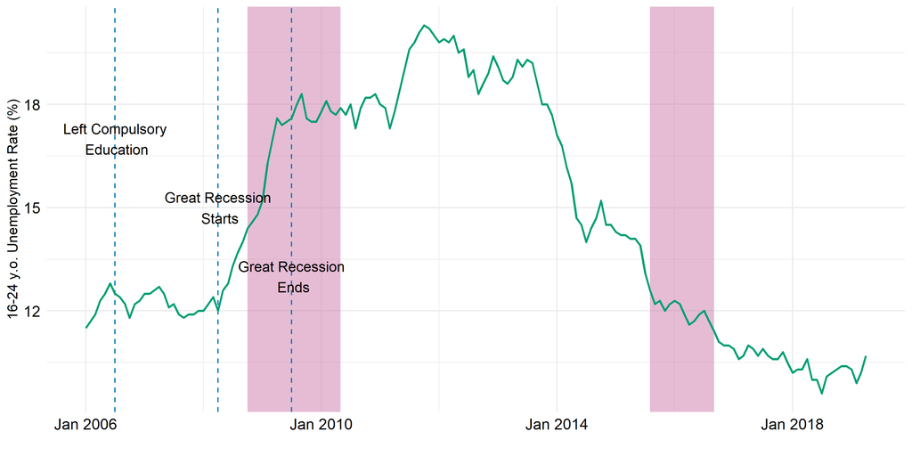

## Moderators

- Gender
- Index of Multiple Deprivation (**IMD**) @ Age 14/15
  - LSOA of residence (400-1,200 households).
  - Higher values indicate greater deprivation
- Family Five Class NS-SEC @ Age 13/14
- Internal and External Locus of Control @ Age 14/15
  - Both sum scores of three items.
  - Higher values indicate greater internal (external) LOC

## Methods

\[GHQ_{Age 25, i} = \beta_{0} + \beta_{1} \cdot NEET_{i} + \beta_{2} \cdot NEET_{i} \cdot M_{i,j} + \beta_{J} \cdot M + \beta_{K} \cdot X_{i}\]

- OLS regression with interaction term for each moderator in turn.
- Survey weights used to account for attrition.
- Missing data imputed using Tilling et al. (2016) method for interactions.
  - m = 50, burn in = 25.
  - Survey weights added as linear term.
- n = 7,363

## Control Variables (\(X_{i}\))

- Health:
  - GHQ-12 Likert @ Age 14/15 & Age 16/17
  - Self-Rated Health @ Age 14/15
  - Disability @ Age 14/15
- Risk:
  - School Attitude @ Age 14/15 (12 item measure)
  - Risk Behaviours @ Age 14/15 (8 item measure)
- Demographics:
  - Ethnicity
  - English Speaking Household @ Age 13/14
  - Household Type @ Age 13/14
  - Education Level @ Age 25

## Descriptive Statistics

|  | Variable | 6+ Months NEET | <6 Months NEET |
| --- | --- | --- | --- |
|  | Female | 732 (55.60%) | 3,440 (56.90%) |
|  | Internal LOC | 5.85 (1.44) | 5.92 (1.40) |
|  | External LOC | 3.65 (1.73) | 2.99 (1.54) |
|  | IMD | 28.11 (18.42) | 22.72 (16.76) |
| Family NS-SEC | Higher | 380 (28.68%) | 2,506 (41.50%) |
|  | Intermediate | 90 (6.78%) | 458 (7.59%) |
|  | Small Employer | 157 (11.84%) | 795 (13.16%) |
|  | Lower Supervisory | 154 (11.60%) | 653 (10.81%) |
|  | (Semi-) Routine | 406 (30.69%) | 1,307 (21.64%) |
|  | Long-Term Unemployed | 138 (10.41%) | 320 (5.31%) |

## Results

### Baseline Model

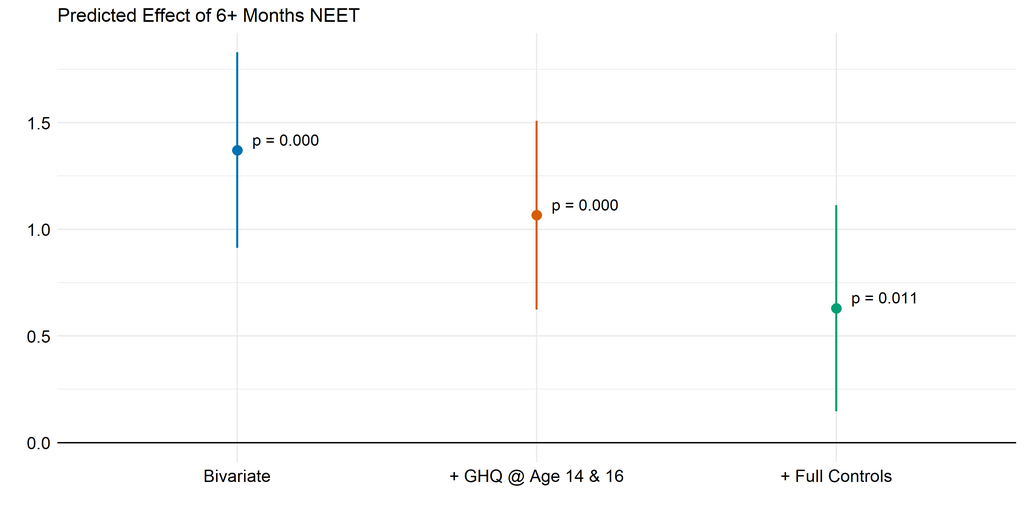

## Results

### Gender

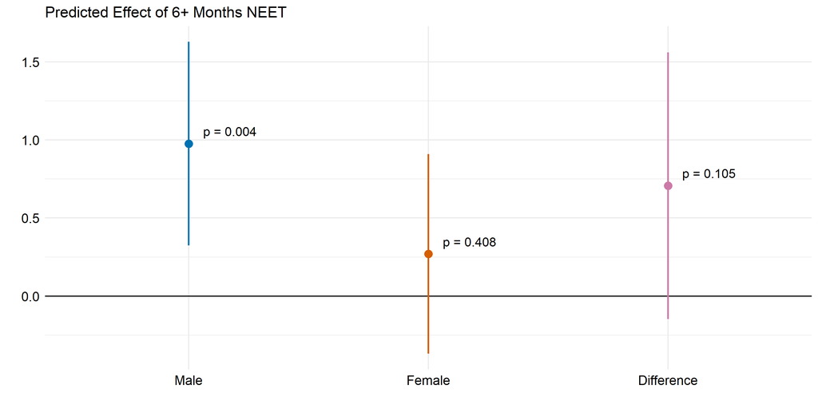

## Results

### Childhood SES

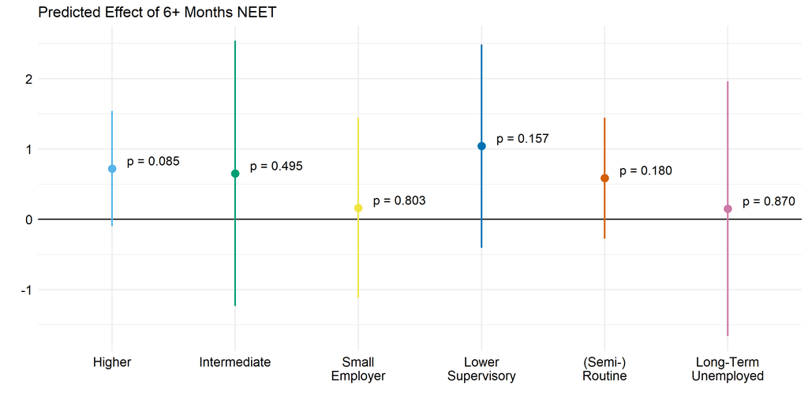

## Results

### Neighbourhood Deprivation

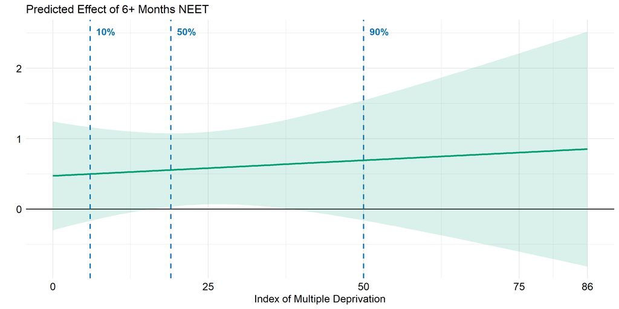

## Results

### Neighbourhood Deprivation

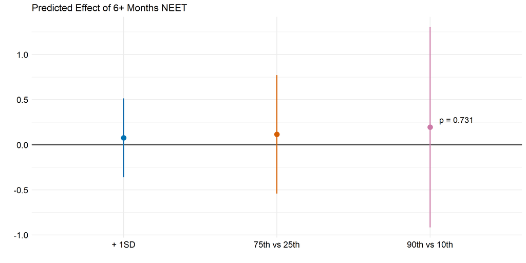

## Results

### Internal Locus of Control

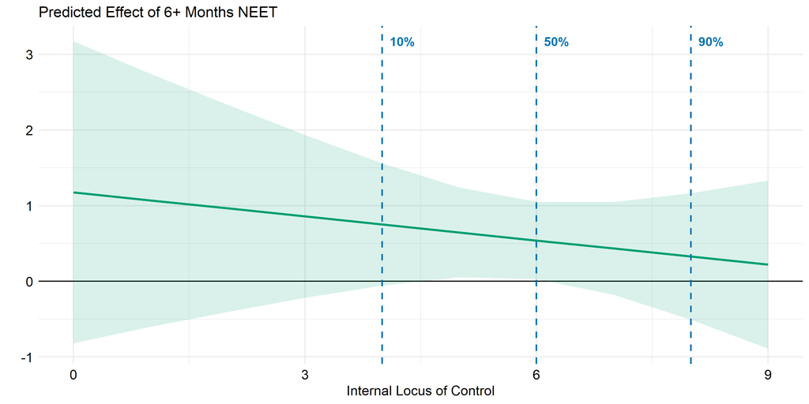

## Results

### Internal Locus of Control

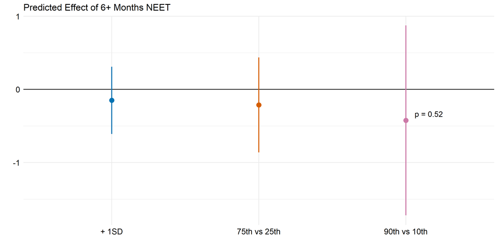

## Results

### External Locus of Control

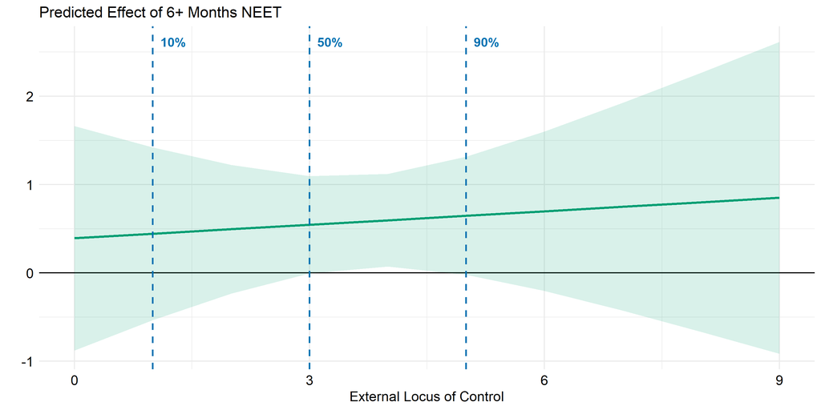

## Results

### External Locus of Control

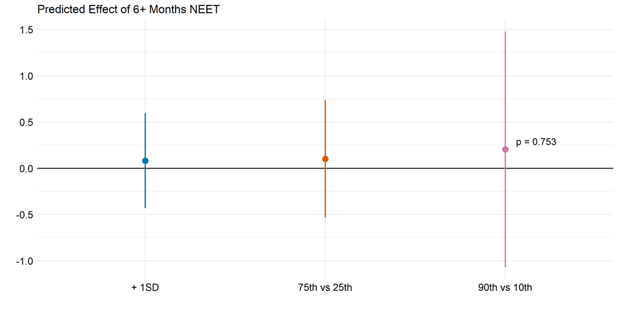

## Discussion

- 6+ month NEET episode associated with poorer mental health 5-7 years later.
- Results consistent with (most) hypotheses, but estimates imprecise
- Research should move from overall associations to moderation and mediation.
- Findings may be specific to cohort entering adulthood during recession.

## Limitations

- NEET concept covers diverse circumstances (Furlong 2006).
- Observational design
- Measurement error
- Collider bias
- High attrition (52.3%)

## Limitations

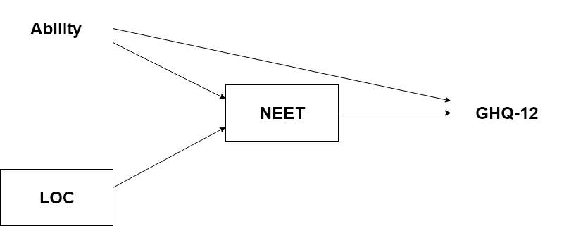

## Acknowledgements

- Professor Jenny Head, Dr Stephen Jivraj, Alexis Karamanos and Dr Tim Morris
- UK Data Service and Centre for Longitudinal Studies, UCL.
- UBEL DTP and the ESRC
- Contributors to StackOverflow and open-source software movement.

Questions: liam.wright.17@ucl.ac.uk

Slides and Code: https://ljwright.rbind.io/

## Appendix

### Regression Results

|  | Basic | Gender | Internal LOC | External LOC | IMD | Family NS-SEC |
| --- | --- | --- | --- | --- | --- | --- |
| 6+ Months NEET | 0.63 [0.147, 1.113] | 0.976 [0.324, 1.628] | 0.550 [0.038, 1.063] | 0.551 [0.007, 1.094] | 0.577 [0.061, 1.093] | 0.720 [-0.099, 1.539] |
| 6+ Months NEET x Female |  | -0.707 [-1.565, 0.151] |  |  |  |  |
| 6+ Months NEET x Internal LOC |  |  | -0.106 [-0.431, 0.218] |  |  |  |
| 6+ Months NEET x External LOC |  |  |  | 0.051 [-0.268, 0.369] |  |  |
| 6+ Months NEET x IMD |  |  |  |  | 0.004 [-0.021, 0.030] |  |
| 6+ Months NEET x Intermediate |  |  |  |  |  | -0.067 [-2.101, 1.967] |
| 6+ Months NEET x Small Employer |  |  |  |  |  | -0.558 [-2.069, 0.953] |
| 6+ Months NEET x Lower Supervisory |  |  |  |  |  | 0.321 [-1.385, 2.026] |
| 6+ Months NEET x (Semi-) Routine |  |  |  |  |  | -0.135 [-1.355, 1.085] |
| 6+ Months NEET x Long-Term Unemployed |  |  |  |  |  | -0.570 [-2.546, 1.406] |

## Appendix

### Figures

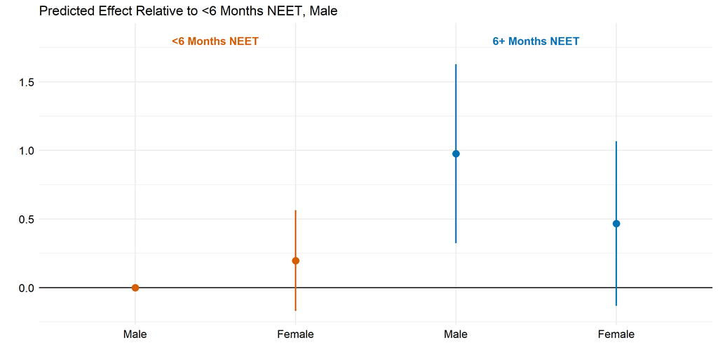

## Appendix

### Figures

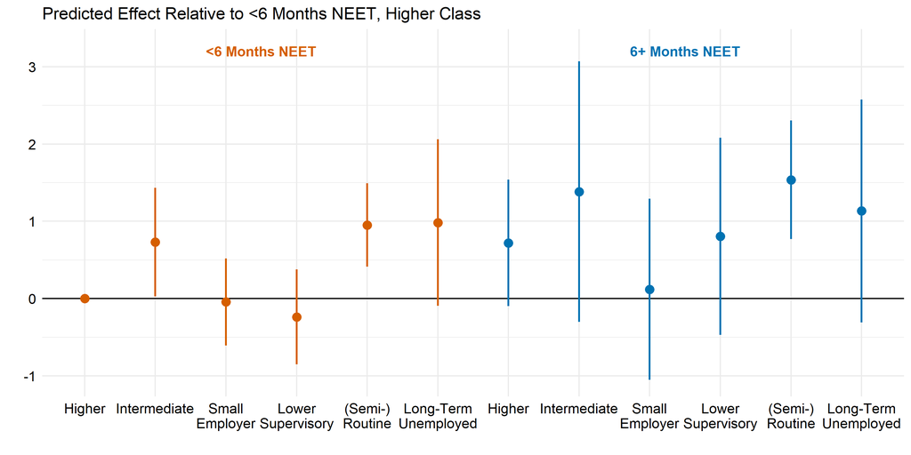

## Appendix

### Figures

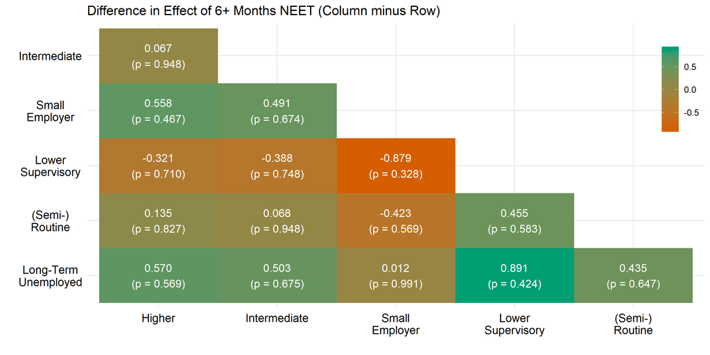

## Appendix

### Figures

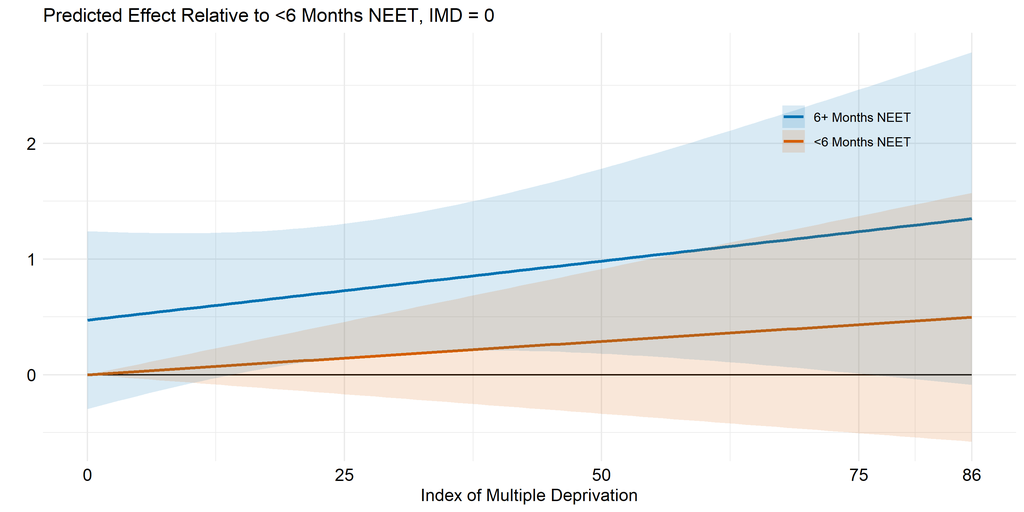

## Appendix

### Figures

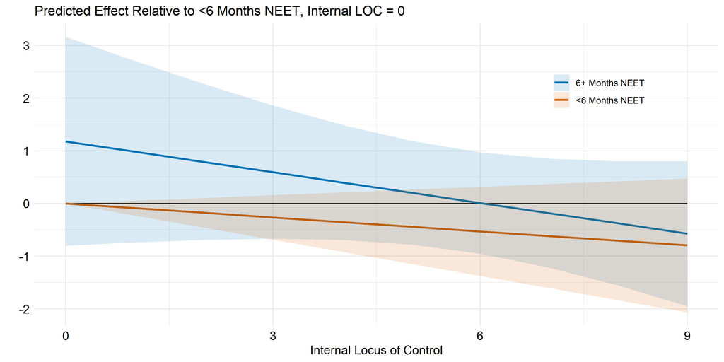

## Appendix

### Figures

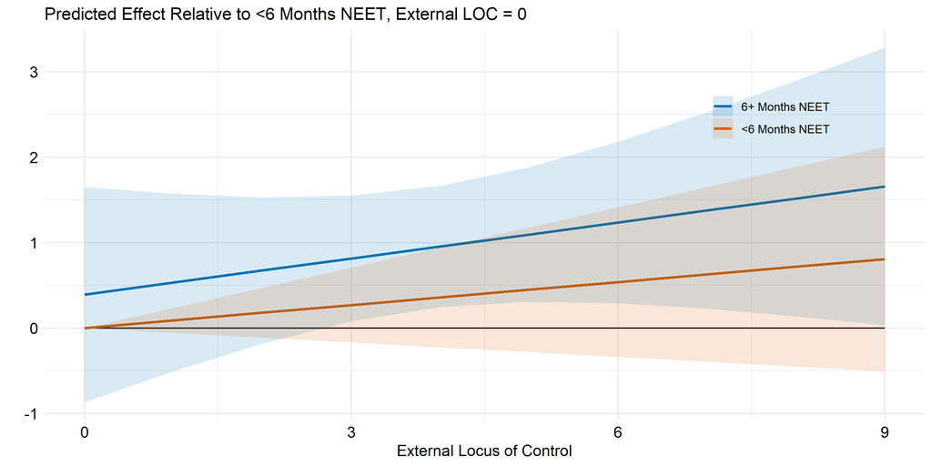

## References

Clark, Andrew E., Yannis Georgellis, and Peter Sanfey. 2001. “Scarring: The psychological impact of past unemployment.” *Economica* 68 (270): 221–41. https://doi.org/10.1111/1468-0335.00243.

Furlong, Andy. 2006. “Not a very NEET solution.” *Work, Employment and Society* 20 (3): 553–69. https://doi.org/10.1177/0950017006067001.

ONS. 2019. “Young people not in education, employment or training (NEET), UK: May 2019.” https://www.ons.gov.uk/employmentandlabourmarket/peoplenotinwork/unemployment/bulletins/youngpeoplenotineducationemploymentortrainingneet/may2019.

Rotter, J. B. 1966. “Generalized expectancies for internal versus external control of reinforcement.” *Psychological Monographs* 80 (1): 1–28. https://doi.org/10.1037/h0092976.

Tilling, Kate, Elizabeth J. Williamson, Michael Spratt, Jonathan A.C. Sterne, and James R. Carpenter. 2016. “Appropriate inclusion of interactions was needed to avoid bias in multiple imputation.” *Journal of Clinical Epidemiology* 80: 107–15. https://doi.org/10.1016/j.jclinepi.2016.07.004.